# Prediction Of Activity Quality From Activity Monitors

Jens Schreiber

August 2015

### Executive Summary

Using devices such as Jawbone Up, Nike FuelBand, and Fitbit it is now possible to collect a large amount of data about personal activity relatively inexpensively. One thing that people regularly do is quantify how much of a particular activity they do, but they rarely quantify how well they do it. In this project, the goal is to use data from accelerometers on the belt, forearm, arm, and dumbell of 6 participants. They were asked to perform barbell lifts correctly and incorrectly in 5 different ways. More information is available from the website here: http://groupware.les.inf.puc-rio.br/har (see the section on the Weight Lifting Exercise Dataset). In order to predict one out five (A,B,C,D,E) “lift methods”, where A is the correct execution of the exercise, the following steps are done:

### Preprocessing

#### Get the data

```r
  registerDoMC(cores = 2)
  set.seed(123456)

  # if data is not on your local storage donwload it first
  #dataTrainUrl <- "http://d396qusza40orc.cloudfront.net/predmachlearn/pml-training.csv"
  #dataTrainSet <- read.csv(url(dataTrainUrl), na.strings=c("NA","#DIV/0!",""))

  #dataSubmissionUrl <- "http://d396qusza40orc.cloudfront.net/predmachlearn/pml-testing.csv"
  #dataSubmissionSet <- read.csv(url(dataSubmissionUrl), na.strings=c("NA","#DIV/0!",""))


  rawData <- read.csv(file="pml-training.csv",na.strings=c("NA","#DIV/0!",""))
  subSamples <- createDataPartition(y=rawData$classe, p=3/4, list=FALSE)
  data.train <- rawData[subSamples, ]
  data.test <- rawData[-subSamples, ]
```

For ease of readness a lot of the actual code is skipped in the report. For detailled information please refer to the code itself. During the preprocessing the following steps were done:

- the first seven colums are removed, because they are not relevant for the prognosis
- rows with any NA values were removed, because a lot of algorithms in the caret package have problems with that
- a correlation matrix was calculated
- a correlation plot is used to determine a cutoff value of 0.5 for the “findCorrelation” function, it seems to be a good balance between correlated and non-correlated features
- all data input is changed according to the former preprocessing

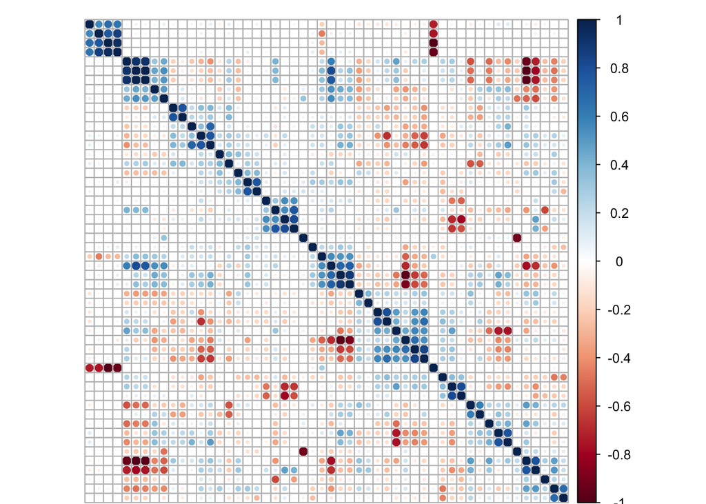

```r
  descrCor <- cor(data.cor,use="all.obs")
  corrplot(descrCor,order="hclust", addCoef.col=NULL,tl.cex=0.1,tl.col="white")
```

```r
  # trim so that only values with a correlation above 0.5 is used
  highlyCorDescr <- findCorrelation(descrCor, cutoff = .5, names=TRUE)
```